# TRABALHO PRÁTICO 2: **Etiquetamento Gramatical com LSTM**

Em aplicações linguísticas, Etiquetamento Gramatical (do inglês, Part-Of-Speech Tagging), também chamada de Marcação Morfológica, é o processo de marcar uma palavra em um texto (corpus) como correspondendo a uma classe gramatical específica, com base na sua definição e no seu contexto. Uma forma simplificada disso é comumente ensinada para crianças em idade escolar, na identificação de palavras como substantivos , verbos , adjetivos , advérbios , etc. Um exemplo de etiquetamento gramatical é dado na seção 2.4.1 da apostila da disciplina, que pode ser acessada através deste [link](https://www.vareto.com.br/ftp/igti/pln-booklet-latex.pdf).

## Descrição dos Dados

Neste desafio, o objetivo é te introduzir de forma prática à tarefa de POS Tagging para a língua Portuguesa. Para isso utilizaremos o corpus [**Mac-Morpho**](http://nilc.icmc.usp.br/macmorpho/), produzido pelo grupo NILC em da ICMC USP. O Mac-Morpho oferece dados para treinamento, validação e teste de modelos preditivos, capazes de classificar a classe gramatical de palavras em Português. Para acessar o conjunto de classes, acesse http://nilc.icmc.usp.br/macmorpho/macmorpho-manual.pdf.

Um exemplo da grasse gramatical *ARTIGO* pode ser visualizada abaixo:

- **O_ART** patinho feio vivia chorando.
- No meio do caminho havia **uma_ART** pedra.
- Era **uma_ART** grande amiga.
- **As_ART** folhas secas caíam no outono.
- **Os_ART** alunos chegaram cedo.
- Tinha **uns_ART** repentes interessantes.
- Era **um_ART** homem de sorte.

O *corpus* da base de dados Mac-Morpho está disponível para download em http://nilc.icmc.usp.br/macmorpho/macmorpho-v3.tgz.

O mesmo encontra-se dividido em seções de treinamento, desenvolvimento e teste: o conjunto de treinamento corresponde a 76% da base de dados, o conjunto de desenvolvimento possui 4% do total de amostras enquanto o conjunto de teste representa 20%. A razão para os números incomuns é que o corpus foi inicialmente estruturado em 80% (treino) / 20% (teste) e, em seguida, 5% da seção do treino foi definida à parte para desenvolvimento. Essa divisão foi usada em muitos estudos, inclusive no [artigo](https://journal-bcs.springeropen.com/articles/10.1186/s13173-014-0020-x). Por esta razão, novas pesquisas de etiquetamento gramatical com Mac-Morpho são encorajadas a segui-la para tornar possíveis comparações consistentes.

**É necessário que você resolva as questões que seguem a fim de responder o questionário do desafio.**

## Bibliotecas essenciais

```python
import matplotlib.pyplot as plt
import nltk
import numpy as np
import os
import pandas as pd
import seaborn as sn
import torch
import zipfile
```

## Baixando os arquivos

```python
macmorpho_file_url = 'https://www.vareto.com.br/ftp/igti/tagging/macmorpho-v3.zip'

if not os.path.isfile('macmorpho-v3.zip'):
    !wget $macmorpho_file_url
    macmorpho_file = zipfile.ZipFile('macmorpho-v3.zip', 'r')
    macmorpho_file.extractall()
```

```
--2021-09-02 15:43:06--  https://www.vareto.com.br/ftp/igti/tagging/macmorpho-v3.zip
Resolving www.vareto.com.br (www.vareto.com.br)... 104.21.49.83, 172.67.160.110, 2606:4700:3036::ac43:a06e, ...
Connecting to www.vareto.com.br (www.vareto.com.br)|104.21.49.83|:443... connected.
HTTP request sent, awaiting response... 200 OK
Length: 2311287 (2.2M) [application/zip]
Saving to: ‘macmorpho-v3.zip’

macmorpho-v3.zip    100%[===================>]   2.20M  5.82MB/s    in 0.4s

2021-09-02 15:43:07 (5.82 MB/s) - ‘macmorpho-v3.zip’ saved [2311287/2311287]
```

## Carregando os arquivos

```python
def read_subset(file_name):
    with open(file_name, 'r', encoding='utf-8') as file_buffer:
        sentences = [row for row in file_buffer]
    return sentences

train_data = read_subset('macmorpho-train.txt')
valid_data = read_subset('macmorpho-dev.txt')
probe_data = read_subset('macmorpho-test.txt')
```

# **Questionário**

Agora cabe a você desenvolver algoritmos na linguagem Python a fim de responder as questões que seguem.

**Informação Importante:** Neste desafio, não realize nenhuma espécie de normalização que não seja de tipografia, como lematização, radicalização, remoção de *stopwords*, etc. Limite-se, somente ao processo de segmentação em sentenças e, posteriormente, em palavras.

## PERGUNTA-01

- Qual o número de categorias (classes) presente em cada um dos conjuntos (treinamento, desenvolvimento e teste)?

```python
def subset_splitter(data_subset, lower=False):
    data_tuples = list()
    for row in data_subset:
        if lower: row = row.lower()
        tuples_list = row.split()
        tuples_list = [element.split('_') for element in tuples_list]
        tokens_list = [token for (token, label) in tuples_list]
        labels_list = [label for (token, label) in tuples_list]
        data_tuples.append( (tokens_list,labels_list) )
    return data_tuples

def subset_categorizer(data_tuples):
    data_labels = set()
    data_tokens = set()
    for tokens,labels in data_tuples:
        data_labels.update(labels)
        data_tokens.update(tokens)
    return data_labels, data_tokens

train_tuples = subset_splitter(train_data, lower=True)
train_labels, train_tokens = subset_categorizer(train_tuples)

valid_tuples = subset_splitter(valid_data, lower=True)
valid_labels, valid_tokens = subset_categorizer(valid_tuples)

probe_tuples = subset_splitter(probe_data, lower=True)
probe_labels, probe_tokens = subset_categorizer(probe_tuples)

assert(len(train_labels) == len(valid_labels) == len(probe_labels))
print('Todos os subconjuntos (treino, validação e teste) possuem {} categorias/classes.'.format(len(train_labels)))
```

```
Todos os subconjuntos (treino, validação e teste) possuem 26 categorias/classes.
```

## PERGUNTA-02

- Qual categoria aparaceu em maior número de vezes no *conjunto de treinamento*?

```python
def vocab_hist_counter(data_tuples, sort=False):
    label_hist = dict()
    vocab_hist = dict()
    for tokens, labels in data_tuples:
        for token in tokens:
            if token in vocab_hist: vocab_hist[token] += 1
            else: vocab_hist[token] = 1
        for label in labels:
            if label in label_hist: label_hist[label] += 1
            else: label_hist[label] = 1
    if sort:
        label_hist = sorted(label_hist.items(), key=lambda tup:tup[1], reverse=True)
        vocab_hist = sorted(vocab_hist.items(), key=lambda tup:tup[1], reverse=True)
    else:
        label_hist = list(label_hist.items())
        vocab_hist = list(vocab_hist.items())
    return label_hist, vocab_hist

train_label_hist, train_vocab_hist = vocab_hist_counter(train_tuples, sort=True)
print('A categoria mais presente é {} com {} aparições.'.format(train_label_hist[0][0].upper(), train_label_hist[0][1]))
train_label_hist[:10]
```

```
A categoria mais presente é N com 156121 aparições.
```

```
[('n', 156121),
 ('pu', 106234),
 ('v', 75935),
 ('nprop', 72030),
 ('prep', 70759),
 ('art', 53139),
 ('prep+art', 45690),
 ('adj', 32873),
 ('adv', 18409),
 ('kc', 17908)]
```

## PERGUNTA-03

Qual o tamanho do vocabulário no *conjunto de treinamento* após a normalização da tipografia?

```python
print('O vocabulário possui {} termos.'.format(len(train_tokens)))
```

```
O vocabulário possui 47236 termos.
```

## PERGUNTA-04

Encontre os termos que estão presentes no conjunto de *validação* e *teste*, mas que não ocorreram no conjunto de treinamento.

- Liste as primeiras 5 (cinco) palavras, em ordem alfabética *crescente*, que estão no conjunto de desenvolvimento (validação) e que NÃO estão no conjunto de treinamento.
- Liste as primeiras 5 (cinco) palavras, em ordem alfabética *decrescente*, que estão no conjunto de teste (avaliação) e que NÃO estão no conjunto de treinamento.

```python
missing_valid = np.setdiff1d(valid_tokens, train_tokens, assume_unique=True)
missing_valid = sorted(missing_valid[0], reverse=False)
print('Palavras do conjunto de validação ausentes: {}'.format(missing_valid[:10]))

missing_probe = np.setdiff1d(probe_tokens, train_tokens, assume_unique=True)
missing_probe = sorted(missing_probe[0], reverse=True)
print('Palavras do conjunto de avaliação ausentes: {}'.format(missing_probe[:10]))
```

```
Palavras do conjunto de validação ausentes: ['!', '"', '%', '&', '&gabbana', "'", '(', ')', ',', '-']
Palavras do conjunto de avaliação ausentes: ['útil', 'úteis', 'únicos', 'único', 'únicas', 'única', 'úmidas', 'últimos', 'último', 'últimas']
```

## PERGUNTA-05

Crie um vocabulário com toda a base de dados, isto é, incluindo todas os termos existentes nos conjuntos de treinamento, desenvolvimento e teste.

- Qual o tamanho do vocabulário considerando toda a base de dados?

```python
database_vocab = train_tokens | valid_tokens | probe_tokens
print('O vocabulário de toda a base de dados possui {} elementos.'.format(len(database_vocab)))
```

```
O vocabulário de toda a base de dados possui 54235 elementos.
```

## PERGUNTA-06

Ordene todos os elementos (*types*) presentes no vocabulário em ordem alfabética a fim de criar uma lista de palavras de *toda a base de dados* de tal forma que o identificador de cada elemento será o seu respectivo índice. Faça a mesma coisa com as etiquetas (categorias/classes).

- Quais os tipos/elementos encontrados nos índices de número '10000' e número '20000'?
- Quais as etiquetas encontradas nos índices de número '10' e número '20'?

```python
idx2token = sorted(database_vocab)
print('Os tipos encontrados nas posições 10000 e 20000 são, respectivamente {} e {}.'.format(idx2token[10000], idx2token[20000]))

idx2label = sorted(train_labels | valid_labels | probe_labels)
print('As tags encontradas nas posições 10 e 20 são, respectivamente {} e {}.'.format(idx2label[10].upper(), idx2label[20].upper()))
```

```
Os tipos encontrados nas posições 10000 e 20000 são, respectivamente billpay e draft.
As tags encontradas nas posições 10 e 20 são, respectivamente NUM e PRO-KS.
```

## PERGUNTA-07

Dada as listas ordenadas, estabelecidas na questão anterior, encontre o índice invertido de ambas. Em outras palavras, gere dicionários onde a palavra corresponde à chave (*key*) e índice seja o valor (*value*).

- Quais os índices das palavras 'bills' e 'draftaram'?
- Quais os índices das etiquetas 'adv-ks' e 'propess'?

```python
token2idx = {token:idx for (idx,token) in enumerate(idx2token)}
print('Os índices encontrados das palavras bills e draftaram são, respectivamente {} e {}.'.format(token2idx['bills'], token2idx['draftaram']))

label2idx = {token:idx for (idx,token) in enumerate(idx2label)}
print('Os índices encontrados das etiquetas adv-ks e propess são, respectivamente {} e {}.'.format(label2idx['adv-ks'], label2idx['propess']))
```

```
Os índices encontrados das palavras bills e draftaram são, respectivamente 10001 e 20001.
Os índices encontrados das etiquetas adv-ks e propess são, respectivamente 2 e 22.
```

## PERGUNTA-08

Dado que você possui gerou o dicionário invertido de tipos (*types*) na questão anterior, encontre o vetor de inteiros para a seguinte sequência:

```
sentence = ['a', 'imaginação', 'é', 'mais', 'importante', 'que', 'o', 'conhecimento', '.']
```

Qual foi o vetor de inteiros obtido?

```python
def prepare_sequence(dictionary, sequence):
    num_sequence = [dictionary[item] for item in sequence]
    return torch.tensor(num_sequence, dtype=torch.long)

sentence = ['a', 'imaginação', 'é', 'mais', 'importante', 'que', 'o', 'conhecimento', '.']
num_sent = prepare_sequence(token2idx, sentence)
num_sent.tolist()
```

```
[3975, 28725, 54086, 33599, 28931, 42970, 37433, 14798, 49]
```

## PERGUNTA-09

Dado que você possui gerou o dicionário invertido de etiquetas (*tags*) na questão anterior, encontre o vetor de inteiros para a seguinte sequência:

```
tags = ['art', 'n', 'pcp', 'v', 'prep', 'prep', 'prep+art', 'n', 'prep', 'nprop', 'nprop', 'pu']
```

Qual foi o vetor de inteiros obtido?

```python
tags = ['art', 'n', 'pcp', 'v', 'prep', 'prep', 'prep+art', 'n', 'prep', 'nprop', 'nprop', 'pu']
num_sent = prepare_sequence(label2idx, tags)
num_sent.tolist()
```

```
[3, 8, 11, 25, 13, 13, 15, 8, 13, 9, 9, 24]
```

# Definição da Rede Neural

O código a seguir é para fazer um modelo LSTM muito simples no PyTorch. A classe `LSTMTagger` representa uma subclasse da classe `torch.nn.Module` de PyTorch para que possa obter todas as funcionalidades da classe base. Se isso é confuso para você, não se preocupe agora, apenas tente e lembre-se disso como uma convenção nas linguagens orientadas a objeto.

```
class LSTMTagger(torch.nn.Module):
    def __init__(self, embedding_dim, hidden_dim, vocab_size, target_size):
        # invocando o construtor da classe base
        super(LSTMTagger, self).__init__()
        # word_embeddings transformam vetores one-hot para uma representação compacta
        self.word_embeddings = torch.nn.Embedding(vocab_size, embedding_dim)
        # A lstm recebe word embeddings como entrada e gera estados ocultos de tamanho hidden_dim.
        self.lstm = torch.nn.LSTM(embedding_dim, hidden_dim)
        # hidden2tag é uma camada linear que mapeia do espaço oculto para o espaço das etiquetas.
        self.hidden2tag = torch.nn.Linear(hidden_dim, target_size)

    def forward(self, sentence):
        embeds = self.word_embeddings(sentence)
        lstm_out, _ = self.lstm(embeds.view(len(sentence), 1, -1))
        tag_space = self.hidden2tag(lstm_out.view(len(sentence), -1))
        tag_scores = torch.nn.functional.log_softmax(tag_space, dim=1)
        return tag_scores
```

Acima, estabelecemos nossa classe que define o modelo neural recorrente que será utilizado: Long short-term memory (LSTM). Enquanto no construtor `__init__()` definimos os componentes de classe `LSTMTagger`, o método `forward()` especifica como esses componentes se relacionam.

**Você deve empregar a classe `LSTMTagger`, disponibilizada acima, no restante deste trabalho.**

# Definição dos Hiperparâmetros

Precisamos agora definir os hiperparâmetros de nossa rede neural! Além dos parâmetros intrínsecos de nosso modelo, podemos destacar a taxa de aprendizado (*learning rate*), a função de erro (*loss function*) e também o número de épocas (*number of epochs*). Estes já foram fornecidos para você.

```
EMBEDDING_DIM = 128
HIDDEN_DIM    = 64
VOCAB_SIZE    = # Qual deve ser o valor utilizado aqui??
TARGET_SIZE   = # Qual deve ser o valor utilizado aqui??
LEARNING_RATE = 0.05
NUM_EPOCHS    = 5

# Inicializar o modelo com todos os parâmetros necessários
model = LSTMTagger(EMBEDDING_DIM, HIDDEN_DIM, VOCAB_SIZE, TARGET_SIZE)

# Empregamos a função de erro denominada Negative Log Likelihood loss (NLLLoss)
loss_function = torch.nn.NLLLoss()

# Empregamos o algoritmo de otimização Stochastic Gradient Descent (SGD)
optimizer = torch.optim.SGD(model.parameters(), lr=LEARNING_RATE)
```

**Você deve estipular quais são os valores que devem ser fornecidos para `VOCAB_SIZE` e `TARGET_SIZE`. Entretanto, para os demais, você deve empregar os hiperparâmetros fornecidos acima no restante deste trabalho.**

```python
class LSTMTagger(torch.nn.Module):
    def __init__(self, embedding_dim, hidden_dim, vocab_size, target_size):
        # invocando o construtor da classe base
        super(LSTMTagger, self).__init__()
        # word_embeddings transformam vetores one-hot para uma representação compacta
        self.word_embeddings = torch.nn.Embedding(vocab_size, embedding_dim)
        # A lstm recebe word embeddings como entrada e gera estados ocultos de tamanho hidden_dim.
        self.lstm = torch.nn.LSTM(embedding_dim, hidden_dim)
        # hidden2tag é uma camada linear que mapeia do espaço oculto para o espaço das etiquetas.
        self.hidden2tag = torch.nn.Linear(hidden_dim, target_size)

    def forward(self, sentence):
        embeds = self.word_embeddings(sentence)
        lstm_out, _ = self.lstm(embeds.view(len(sentence), 1, -1))
        tag_space = self.hidden2tag(lstm_out.view(len(sentence), -1))
        tag_scores = torch.nn.functional.log_softmax(tag_space, dim=1)
        return tag_scores
```

```python
EMBEDDING_DIM = 128
HIDDEN_DIM    = 64
VOCAB_SIZE    = len(token2idx.keys())
TARGET_SIZE   = len(label2idx.keys())
LEARNING_RATE = 0.05
NUM_EPOCHS    = 5

# Inicializar o modelo com todos os parâmetros necessários
model = LSTMTagger(EMBEDDING_DIM, HIDDEN_DIM, VOCAB_SIZE, TARGET_SIZE)

# Empregamos a função de erro denominada Negative Log Likelihood loss (NLLLoss)
loss_function = torch.nn.NLLLoss()

# Empregamos o algoritmo de otimização Stochastic Gradient Descent (SGD)
optimizer = torch.optim.SGD(model.parameters(), lr=LEARNING_RATE)
```

## PERGUNTA-10

Dado a classe `LSTMTagger` acima, qual a melhor definição para o parâmetro `vocab_size`?

1. Quantidade de palavras disponíveis no *corpus* e, consequentemente, o tamanho do vetor one-hot.
2. Tamanho da sentença/frase que é fornecida como entrada para a rede neural.
3. Quantidade de categorias/etiquetas que caracterizam cada uma das palavras do *corpus*.
4. Tamanho da representação compacta que é capaz de representar palavras de forma numérica.

## PERGUNTA-11

Dado a classe `LSTMTagger` acima, qual a melhor definição para o parâmetro `target_size`?

1. Quantidade de palavras disponíveis no *corpus* e, consequentemente, o tamanho do vetor one-hot.
2. Tamanho da sentença/frase que é fornecida como entrada para a rede neural.
3. Quantidade de categorias/etiquetas que caracterizam cada uma das palavras do *corpus*.
4. Tamanho da representação compacta que é capaz de representar palavras de forma numérica.

## PERGUNTA-12

A função `prepare_sequence(dictionary, sequence)` recebe o dicionário conversor gerado e uma lista de *strings*, tanto para conversão de palavras quanto etiquetas, e retorna uma lista numérica equivalente do tipo `torch.Tensor`.

```
def prepare_sequence(dictionary, sequence):
    num_sequence = [dictionary[item] for item in sequence]
    return torch.tensor(num_sequence, dtype=torch.long)
```

O trecho abaixo é uma boa dica para implementar o treinamento de sua rede LSTM. Você deve se atentar quanto à estrutura das variáveis `training_data` (conjunto de treinamento), `num_sentence` (representação numérica das palavras), `num_tags` (representação numérica das etiquetas)

```
print("TRAINING STAGE")
for epoch in range(NUM_EPOCHS):
    print('Current EPOCH: {}/{}'.format(epoch+1, NUM_EPOCHS), end='\t')
    for words, tags in train_data:
        # Zerar os gradientes para que sejam computados independentemente
        model.zero_grad()
        # Transformar vetor de palavras em vetor numérico (semelhante PERGUNTA-08)
        num_words = prepare_sequence(word2idx, words)
        # Transformar vetor de etiquetas em vetor numérico (semelhante PERGUNTA-09)
        num_tags = prepare_sequence(tag2idx, tags)
        # Fazer a passagem dos dados pela rede (forward pass)
        pred_tags = model(num_words)
        # Encontrar erro e otimizar parâmetros da rede recorrente
        loss = loss_function(pred_tags, num_tags)
        loss.backward()
        optimizer.step()
    # Impedir que gradiente seja atualizado durante a validação
    with torch.no_grad():
        record = list()
        for words, tags in valid_data:
            # Transformar vetor de palavras em vetor numérico (semelhante PERGUNTA-08)
            num_words = prepare_sequence(word2idx, words)
            # Transformar vetor de etiquetas em vetor numérico (semelhante PERGUNTA-09)
            num_tags = prepare_sequence(tag2idx, tags)
            # Fazer a passagem dos dados pela rede (forward pass)
            pred_tags = model(num_words)
            # Encontrar etiqueta com maior probabilidade para cada palavra
            _, max_tags = torch.max(pred_tags, 1)
            # Computar quantas palavras são classificadas de forma correta
            bool_check = [p_label==y_label for (p_label,y_label) in zip(max_tags, num_tags)]
            # Adicionar cálculo à variável de registro
            record.extend(bool_check)
    print('Validation Accuracy: {}'.format(sum(record)/len(record)))
```

- Em qual intervalo está a acurácia encontrada no conjunto de desenvolvimento (validação) após 5 épocas (EPOCHS)?

```python
device = torch.device("cuda:0" if torch.cuda.is_available() else "cpu")
print('Hardware available: {}'.format(device))

model.to(device)
```

```
Hardware available: cuda:0
```

```
LSTMTagger(
  (word_embeddings): Embedding(54235, 128)
  (lstm): LSTM(128, 64)
  (hidden2tag): Linear(in_features=64, out_features=26, bias=True)
)
```

```python
print("TRAINING STAGE")
for epoch in range(NUM_EPOCHS):
    print('Current EPOCH: {}/{}'.format(epoch+1, NUM_EPOCHS), end='\t')
    for tokens, labels in train_tuples:
        # Zerar os gradientes para que sejam computados independentemente
        model.zero_grad()
        # Transformar vetor de palavras em vetor numérico (semelhante PERGUNTA-08)
        num_tokens = prepare_sequence(token2idx, tokens).to(device)
        # Transformar vetor de etiquetas em vetor numérico (semelhante PERGUNTA-09)
        num_labels = prepare_sequence(label2idx, labels).to(device)
        # Fazer a passagem dos dados pela rede (forward pass)
        pred_labels = model(num_tokens)
        # Encontrar erro e otimizar parâmetros da rede recorrente
        loss = loss_function(pred_labels, num_labels)
        loss.backward()
        optimizer.step()

    # Impedir que gradiente seja atualizado durante a validação
    with torch.no_grad():
        record = list()
        for tokens, labels in valid_tuples:
        	# Transformar vetor de palavras em vetor numérico (semelhante PERGUNTA-08)
            num_tokens = prepare_sequence(token2idx, tokens).to(device)
            # Transformar vetor de etiquetas em vetor numérico (semelhante PERGUNTA-09)
            num_labels = prepare_sequence(label2idx, labels).to(device)
            # Fazer a passagem dos dados pela rede (forward pass)
            pred_labels = model(num_tokens)
            # Encontrar etiqueta com maior probabilidade para cada palavra
            _, max_labels = torch.max(pred_labels, 1)
            # Computar quantas palavras são classificadas de forma correta
            bool_check = [p_label==y_label for (p_label,y_label) in zip(max_labels, num_labels)]
            # Adicionar cálculo à variável de registro
            record.extend(bool_check)
    print('Validation Accuracy: {}'.format(sum(record)/len(record)))
```

```
TRAINING STAGE
Current EPOCH: 1/5	Validation Accuracy: 0.8184717297554016
Current EPOCH: 2/5	Validation Accuracy: 0.8452457189559937
Current EPOCH: 3/5	Validation Accuracy: 0.8580540418624878
Current EPOCH: 4/5	Validation Accuracy: 0.86512690782547
Current EPOCH: 5/5	Validation Accuracy: 0.8723283410072327
```

## PERGUNTA-13

Na PERGUNTA-12 foi disponibilizado o código que computa o treino e verifica a acurácia da rede neural recorrente sobre os dados de validação (desenvolvimento) ao final de cada época. Agora, implemente a avaliação do mesmo sobre o conjunto de testes lembrando de utilizar o comando `torch.no_grad()`.

- Em qual intervalo está a acurácia encontrada no conjunto de testes (avaliação)?

```python
# Impedir que gradiente seja atualizado durante
y_true = list()
y_pred = list()
with torch.no_grad():
    record = list()
    for tokens, labels in probe_tuples:
        # Transformar vetor de palavras em vetor numérico (semelhante PERGUNTA-08)
        num_tokens = prepare_sequence(token2idx, tokens).to(device)
        # Transformar vetor de etiquetas em vetor numérico (semelhante PERGUNTA-09)
        num_labels = prepare_sequence(label2idx, labels).to(device)
        # Fazer a passagem dos dados pela rede (forward pass)
        pred_labels = model(num_tokens)
        # Encontrar etiqueta com maior probabilidade para cada palavra
        _, max_labels = torch.max(pred_labels, 1)
        # Computar quantas palavras são classificadas de forma correta
        bool_check = [p_label==y_label for (p_label,y_label) in zip(max_labels, num_labels)]
        # Adicionar cálculo à variável de registro
        y_true.extend(num_labels)
        y_pred.extend(max_labels)
        record.extend(bool_check)
print('Evaluation Accuracy: {}'.format(sum(record)/len(record)))
```

```
Evaluation Accuracy: 0.8578428030014038
```

## PERGUNTA-14

Gere uma matriz de confusão com os dados disponíveis para teste. A mesma pode ser criada utilizando o método [`confusion_matrix`](https://scikit-learn.org/stable/modules/generated/sklearn.metrics.confusion_matrix.html) da biblioteca *Sklearn*.

- Quais etiquetas apresentaram maior incidência de erro?

```python
from sklearn.metrics import confusion_matrix

tags = list(label2idx.keys())
y_true = [idx2label[idx] for idx in y_true]
y_pred = [idx2label[idx] for idx in y_pred]

conf_matrix = confusion_matrix(y_true, y_pred, labels=tags)
```

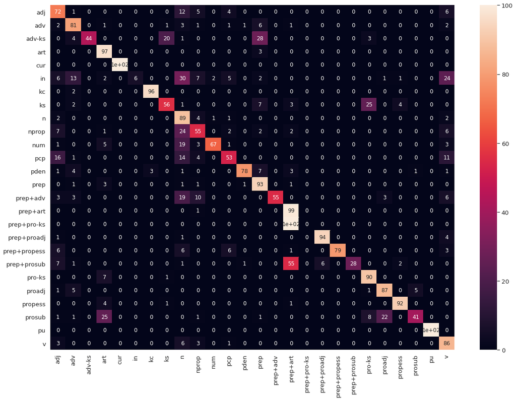

```python
plt.figure(figsize=(20,14))
df_conf_matrix = pd.DataFrame(conf_matrix, tags, tags)
df_conf_matrix_norm = df_conf_matrix.apply(lambda x: round(100*x/sum(x)), axis = 1)
sn.set(font_scale=1.2)
sn.heatmap(df_conf_matrix_norm, annot=True, annot_kws={"size": 12})
plt.show()
```

```python
diagonal = pd.DataFrame(np.diag(df_conf_matrix_norm), index=[df_conf_matrix_norm.index, df_conf_matrix_norm.columns])
diagonal
```

|  |  | 0 |
| --- | --- | --- |
| adj | adj | 72.0 |
| adv | adv | 81.0 |
| adv-ks | adv-ks | 44.0 |
| art | art | 97.0 |
| cur | cur | 100.0 |
| in | in | 6.0 |
| kc | kc | 96.0 |
| ks | ks | 56.0 |
| n | n | 89.0 |
| nprop | nprop | 55.0 |
| num | num | 67.0 |
| pcp | pcp | 53.0 |
| pden | pden | 78.0 |
| prep | prep | 93.0 |
| prep+adv | prep+adv | 55.0 |
| prep+art | prep+art | 99.0 |
| prep+pro-ks | prep+pro-ks | 0.0 |
| prep+proadj | prep+proadj | 94.0 |
| prep+propess | prep+propess | 79.0 |
| prep+prosub | prep+prosub | 28.0 |
| pro-ks | pro-ks | 90.0 |
| proadj | proadj | 87.0 |
| propess | propess | 92.0 |
| prosub | prosub | 41.0 |
| pu | pu | 100.0 |
| v | v | 86.0 |

```python
res_tuples = [(tag, pred[0]) for (tag, pred) in zip(tags, diagonal.values.tolist())]
sorted(res_tuples, key=lambda tup:tup[1])
```

```
[('prep+pro-ks', 0.0),
 ('in', 6.0),
 ('prep+prosub', 28.0),
 ('prosub', 41.0),
 ('adv-ks', 44.0),
 ('pcp', 53.0),
 ('nprop', 55.0),
 ('prep+adv', 55.0),
 ('ks', 56.0),
 ('num', 67.0),
 ('adj', 72.0),
 ('pden', 78.0),
 ('prep+propess', 79.0),
 ('adv', 81.0),
 ('v', 86.0),
 ('proadj', 87.0),
 ('n', 89.0),
 ('pro-ks', 90.0),
 ('propess', 92.0),
 ('prep', 93.0),
 ('prep+proadj', 94.0),
 ('kc', 96.0),
 ('art', 97.0),
 ('prep+art', 99.0),
 ('cur', 100.0),
 ('pu', 100.0)]
```